# Unsupervised Analyses

Nov 24, 2019

First, we will install a few R package

```r
install.packages(rafalib)
```

Then, we load a few R packages

```r
library(here)
library(tidyverse)
library(rafalib)
```

# Motivation

In this lecture, we will be analyzing some genomics data measured through high-throughput technologies, which measure thousands of features at a time. Examples of features are image pixel intensities, genes, single base locations of the genome, or genomic regions. Each specific measurement product is defined by a specific set of features. For example, a specific gene expression microarray product is defined by the set of genes that it measures.

The lecture material came from these resources:

- http://genomicsclass.github.io/book/pages/clustering_and_heatmaps.html
- http://genomicsclass.github.io/book/pages/eda_with_pca.html

A specific study will typically use one product to make measurements on several experimental units, such as individuals. The most common experimental unit will be the individual, but they can also be defined by other entities, for example different parts of a tumor.

Here, we show an example for which we measure RNA expression for 8,793 genes from blood taken from 208 individuals. In this case the data was originally collected to compare gene expression across ethnic groups. The study is described in [this paper](http://www.ncbi.nlm.nih.gov/pubmed/17206142), which claimed that roughly 50% of genes where differentially expressed when comparing blood from two ethnic groups.

In the lecture about dimensionality reduction, we talked about having a set of $n$ observations $X_{1},...,X_{n}$ each with $p$ features. The goal there was to understand the relationships between them or patterns in them. After identifying the most informative features, we might be interested in grouping the observations or samples in some way (e.g. clustering approaches). Both of these are a form of *unsupervised* analyses.

Some types of techniques for unsupervised analyses include:

- Clustering
- Principal components analysis/SVD
- Factor analysis
- Kernel density estimation
- Multidimensional scaling (MDS)
- ICA
- … and many more!

In contrast, we have already discussed the *supervised* setting where we have some covariates $X$ and some outcome $Y$ and we are interested in solving something like $\arg\min_{f} E[(Y−f(X))^2]$.

In this lecture, we will use exploratory data analysis (EDA) and apply unsupervised methods to ask the questions:

**How big is the variation between different ethnic groups? Do samples from the different ethnic groups cluster by ethnicity or by something else?**

## Data

The data we will use comes from [this paper](https://www.ncbi.nlm.nih.gov/pubmed/17206142) which looked at differences in gene expression data across three ethnic populations.

A [gene expression](https://en.wikipedia.org/wiki/Gene_expression) data set obtained from a microarray experiment. [Read more about the specific experiment here](https://www.ncbi.nlm.nih.gov/geo/query/acc.cgi?acc=GSE5859). There are two data sets we will use (both are available on GitHub in the course repo [`/data`](https://github.com/jhu-advdatasci/2019/tree/master/data)):

1. The gene expression intensities (called `exprs_GSE5859.csv`) where the rows represent the features on the microarray (e.g. genes) and the columns represent the different microarray samples.
2. An annotation table (called `sampleinfo_GSE5859.csv`) that contains the information about each of the samples (columns in the gene expression data set) such as the sex, the age, the treatment status, the date the samples were processed. Each row represents one sample.

The data are available on the GitHub course repo `/data`, so once we pull the changes locally, we can read in the data into R.

```r
exprs <- read_csv(here("data", "GSE5859_exprs.csv"))
sampleinfo <- read_csv(here("data", "GSE5859_sampleinfo.csv"))
```

Let’s take a peek at the `exprs` data

```r
dim(exprs)
```

```
## [1] 8793  209
```

```r
exprs[1:5, 1:5]
```

```
## # A tibble: 5 x 5
##   X1      GSM25581.CEL.gz GSM25681.CEL.gz GSM136524.CEL.gz GSM136707.CEL.gz
##   <chr>             <dbl>           <dbl>            <dbl>            <dbl>
## 1 1007_s…            6.33            5.74             6.16             6.51
## 2 1053_at            7.26            7.40             7.49             7.01
## 3 117_at             5.76            4.83             5.04             5.41
## 4 121_at             6.94            7.03             7.54             7.96
## 5 1255_g…            3.60            3.11             3.13             3.36
```

We see there is one column called `X1` and then others that all start with `GSM`. The first column describes the $p=8793$ features and the $N=208$ observations (or microarray samples).

Let’s get rid of that first column and convert the data frame into a matrix.

```r
exprs <- as.matrix(exprs[,-1])
```

We could plot what the gene expression looks like for all the genes in the first four observations (or microarray samples)

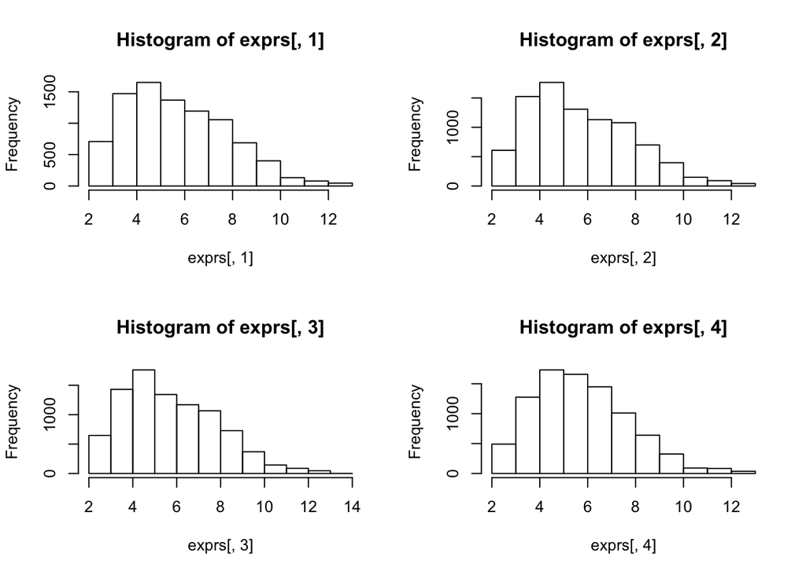

```r
par(mfrow=c(2,2))
hist(exprs[,1])
hist(exprs[,2])
hist(exprs[,3])
hist(exprs[,4])
```

We see it looks unimodal with a right-skewed tail.

Boxplots are often another good way to plot a reasonable number of samples.

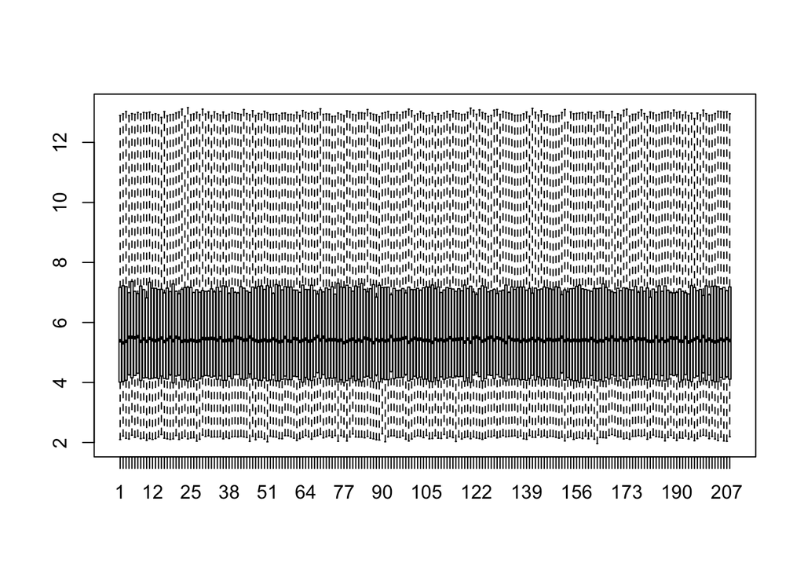

```r
boxplot(exprs,range=0,names=1:ncol(exprs))
```

Note that the number of samples is a bit too large here, making it hard to see the boxes. One can instead simply show the boxplot summaries without the boxes:

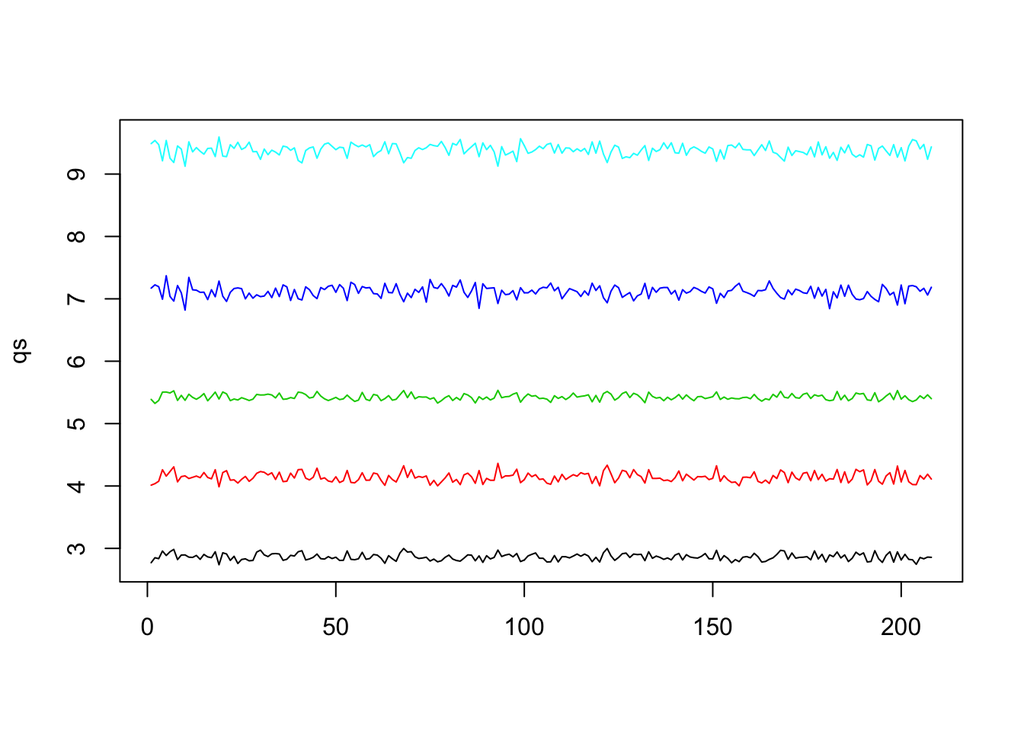

```r
qs <- t(apply(exprs,2,quantile,prob=c(0.05,0.25,0.5,0.75,0.95)))
matplot(qs,type="l",lty=1)
```

We refer to this figure as a *kaboxplot* because [Karl Broman](https://kbroman.org) was the first we saw use it as an alternative to boxplots.

We can also explore the `sampleinfo` table to see what’s in it.

```r
head(sampleinfo)
```

```
## # A tibble: 6 x 4
##   ethnicity date       filename        sex
##   <chr>     <date>     <chr>           <chr>
## 1 CEU       2003-02-04 GSM25349.CEL.gz M
## 2 CEU       2003-02-04 GSM25350.CEL.gz M
## 3 CEU       2002-12-17 GSM25356.CEL.gz M
## 4 CEU       2003-01-30 GSM25357.CEL.gz M
## 5 CEU       2003-01-03 GSM25358.CEL.gz M
## 6 CEU       2003-01-16 GSM25359.CEL.gz M
```

We see there is information about `ethnicity`, `date`, the `filename` (or microarray sample), and the `sex` of the individual.

How many ethnicities are there in this dataset?

```r
table(sampleinfo$ethnicity)
```

```
##
## ASN CEU HAN
##  82 102  24
```

Looks like there are three:

- ASN = Japanese in Tokyo, Japan
- CEU = Northern Europeans from Utah
- HAN = Chinese in Beijing, China

Now, if we want to use this information (e.g. `ethnicity`), to see how the gene expression changes across ethnicity, then we will need to make sure the columns in the `exprs` matrix match the order of the rows of the `sampleinfo` table.

For example, we can look at `exprs`

```r
exprs[1:5,1:5]
```

```
##      GSM25581.CEL.gz GSM25681.CEL.gz GSM136524.CEL.gz GSM136707.CEL.gz
## [1,]        6.333951        5.736190         6.156754         6.513010
## [2,]        7.255622        7.399993         7.491967         7.006123
## [3,]        5.760106        4.825169         5.039387         5.414160
## [4,]        6.935451        7.025210         7.543667         7.959781
## [5,]        3.597872        3.108801         3.128269         3.364947
##      GSM25553.CEL.gz
## [1,]        6.061013
## [2,]        7.250995
## [3,]        5.205697
## [4,]        7.223323
## [5,]        3.125909
```

We can compare the column names in the `exprs` matrix to the `sampleinfo$filename` column. If they are different, then we will need to re-order them.

```r
sampleinfo$filename == colnames(exprs)
```

```
##   [1] FALSE FALSE FALSE FALSE FALSE FALSE FALSE FALSE FALSE FALSE FALSE
##  [12] FALSE FALSE FALSE FALSE FALSE FALSE FALSE FALSE FALSE FALSE FALSE
##  [23] FALSE  TRUE FALSE FALSE FALSE FALSE FALSE FALSE FALSE FALSE FALSE
##  [34] FALSE FALSE FALSE FALSE FALSE FALSE FALSE FALSE FALSE FALSE FALSE
##  [45] FALSE FALSE FALSE FALSE FALSE FALSE FALSE FALSE FALSE FALSE FALSE
##  [56] FALSE FALSE FALSE FALSE FALSE FALSE FALSE FALSE FALSE FALSE FALSE
##  [67] FALSE FALSE FALSE FALSE FALSE FALSE FALSE FALSE FALSE FALSE FALSE
##  [78] FALSE FALSE FALSE FALSE FALSE FALSE FALSE FALSE FALSE FALSE FALSE
##  [89] FALSE FALSE FALSE FALSE FALSE FALSE FALSE FALSE FALSE FALSE FALSE
## [100] FALSE FALSE FALSE FALSE FALSE FALSE FALSE FALSE FALSE FALSE FALSE
## [111] FALSE FALSE FALSE FALSE FALSE FALSE FALSE FALSE FALSE FALSE FALSE
## [122] FALSE FALSE FALSE FALSE FALSE FALSE FALSE FALSE FALSE FALSE FALSE
## [133] FALSE FALSE FALSE FALSE FALSE FALSE FALSE FALSE FALSE FALSE FALSE
## [144] FALSE FALSE FALSE FALSE FALSE FALSE FALSE FALSE FALSE FALSE FALSE
## [155] FALSE FALSE FALSE FALSE FALSE FALSE FALSE FALSE FALSE FALSE FALSE
## [166] FALSE FALSE FALSE FALSE FALSE FALSE FALSE FALSE FALSE FALSE FALSE
## [177] FALSE FALSE FALSE FALSE FALSE FALSE FALSE FALSE FALSE FALSE FALSE
## [188] FALSE FALSE FALSE FALSE FALSE FALSE FALSE FALSE FALSE FALSE FALSE
## [199] FALSE FALSE FALSE FALSE FALSE FALSE FALSE FALSE FALSE FALSE
```

Two useful functions are `any()` and `all()` which take as input a set of logical vectors and test if any or all the logical vectors are true.

```r
all(sampleinfo$filename == colnames(exprs))
```

```
## [1] FALSE
```

Nope! They are not the same order. Let’s fix that.

Here we re-order the columns of the `exprs` dataset using the `match()` function to make sure the order of the columns in the `exprs` matrix match the order of the rows of the `sampleinfo` table.

```r
exprs <- exprs[,match(sampleinfo$filename,colnames(exprs))]

# sanity check
all(sampleinfo$filename == colnames(exprs))
```

```
## [1] TRUE
```

# Clustering

If we want to cluster samples into groups, some questions you might immediately ask are:

- How do we define close?
- How do we group things?
- How do we visualize the grouping?
- How do we interpret the grouping?

## Distance

First, let’s talk about how we can define “distance”. Consider the location of Baltimore and Washington DC defined with (X,Y) coordiante points on a Cartesian plane.

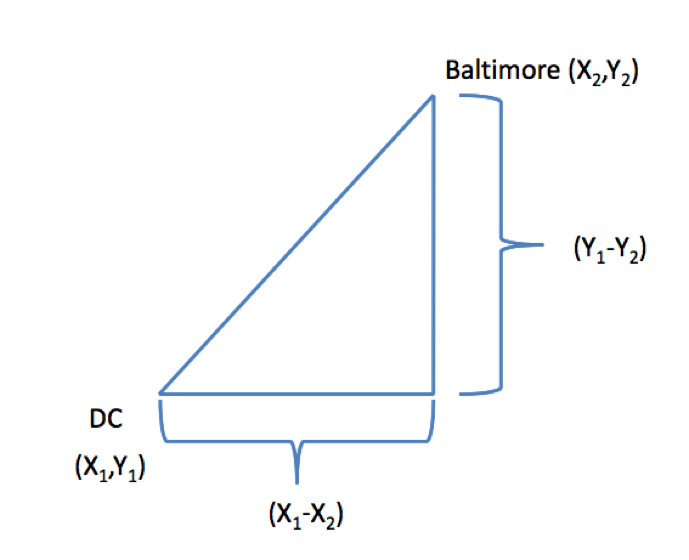

[[ image source](http://rafalab.jhsph.edu/688/lec/lecture5-clustering.pdf)]

### Euclidean distance

The euclidean distance between Baltimore and DC is:

$$\sqrt{ (X_1-X_2)^2 + (Y_1-Y_2)^2} = (|X_1-X_2|^{2} + |Y_1-Y_2|^{2})^{1/2}$$
or

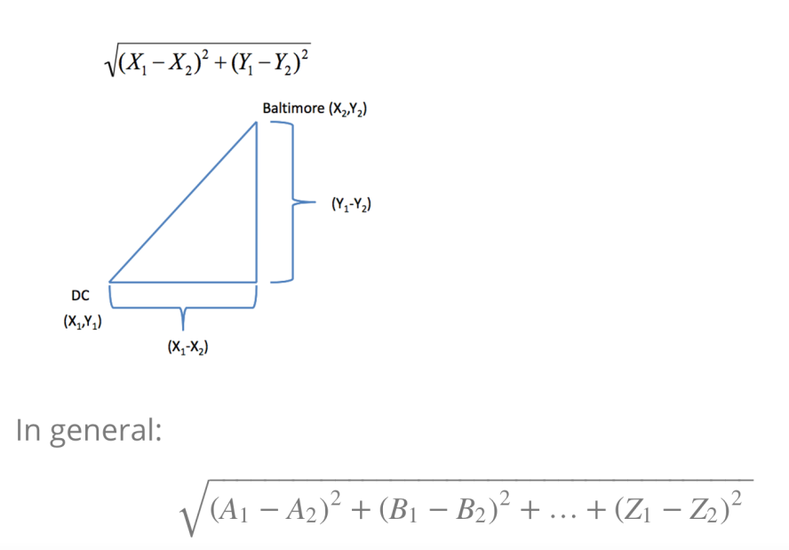

We have previously learned how to use the `dist()` function to calculate the Euclidean distance.

Let’s pretend that we don’t know these are different ethnicities and are interested in clustering. The first step is to compute the distance between each sample:

```r
d = dist(t(exprs), method = "euclidean")
str(as.matrix(d)) # should be 208 x 208
```

```
##  num [1:208, 1:208] 0 19 47.8 47.6 47.7 ...
##  - attr(*, "dimnames")=List of 2
##   ..$ : chr [1:208] "GSM25349.CEL.gz" "GSM25350.CEL.gz" "GSM25356.CEL.gz" "GSM25357.CEL.gz" ...
##   ..$ : chr [1:208] "GSM25349.CEL.gz" "GSM25350.CEL.gz" "GSM25356.CEL.gz" "GSM25357.CEL.gz" ...
```

We can look at the pairwise distances using the `image()` function.

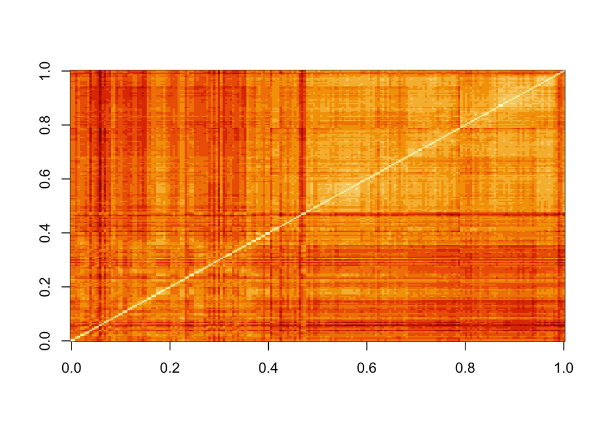

```r
image(as.matrix(d))
```

The image suggests there is at least one cluster of individuals, but unclear about much else.

### Manhattan distance

In constrast to a Euclidean distance, a Manhattan (or taxicab) distance is the sum of the absolute differences of the Cartesian coordiantes.

$$|X_1-X_2| + |Y_1-Y_2|$$
The term “taxicab” comes from the distance a car would drive in a city laid out in square blocks (if there are no one-way streets). The taxicab metric is also known as rectilinear distance or $L_1$ distance.

In the picture below, the the red, yellow, and blue paths (taxicab geometry) all have the same shortest path length of 12. In Euclidean geometry, the green line has length $6\sqrt{2} \approx 8.49$, and is the unique shortest path.

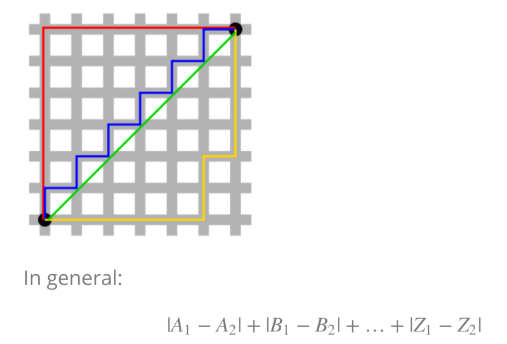

[[ image source](http://en.wikipedia.org/wiki/Taxicab_geometry)]

There are lots of other distance metrics too such as

- **Minkowski distance** = generalized $L_p$-norm of the difference

$$d_p(x,y) = || x - y ||_{p} = ( \sum_{i=1}^n |x_i - y_i|^{p})^{1/p}$$

- **Chebyshev distance** = is the $L_{\infty}$-norm of the difference, a special case of the Minkowski distance where $p$ goes to infinity. It is also known as Chessboard distance.

$$d(x,y) = || x - y ||_{\infty} = \underset{p\rightarrow \infty}{\lim} ( \sum_{i=1}^n |x_i - y_i|^{p})^{1/p} = \underset{i}{\max} |x_i - y_i |$$

- **Canberra distance** = a weighted version of the Manhattan distance, introduced and refined 1967 by Lance, Williams and Adkins. It is often used for data scattered around an origin, as it is biased for measures around the origin and very sensitive for values close to zero.

$$d(x,y) = \sum_{i=1}^n \frac{|x_i - y_i|}{|x_i| + |y_i|}$$

- **Pearson’s distance** = a correlation distance based on Pearson’s product-momentum correlation coefficient of the two sample vectors. Since the correlation coefficient falls between [-1, 1], the Pearson distance lies in [0, 2] and measures the linear relationship between the two vectors.

$$d(x,y) = 1 - \textbf{Corr}(x,y)$$

- **Cosine distance** = contains the dot product scaled by the product of the Euclidean distances from the origin. It represents the angular distance of two vectors while ignoring their scale.
- **Hamming distance** = metric for comparing two binary data strings. While comparing two binary strings of equal length, Hamming distance is the number of bit positions in which the two bits are different. It is a fundamental distance measure in information theory but less relevant in non-integer numerical problems.

## Hierarchical clustering

Now that we have computed the distance between each of the samples, how can we cluster them into groups?

Once approach is called *Hierarchical clustering*. This is an agglomerative (“bottom up” aka each observation starts in its own cluster, and pairs of clusters are merged as one moves up the hierarchy) approach:

- Initially: every sample is its own group
- Then, find closest two things
- Put them together
- Find next closest, until there is only one group

It requires

- A defined distance
- A merging approach

It produces:

- A tree showing how close things are to each other

For this, we will use the `hclust()` function.

```r
hc <- hclust(d)
```

This function returns an `hclust` object that describes the groupings that were created using the algorithm described above.

```r
hc
```

```
##
## Call:
## hclust(d = d)
##
## Cluster method   : complete
## Distance         : euclidean
## Number of objects: 208
```

The `plot()` method represents these relationships with a tree or dendrogram:

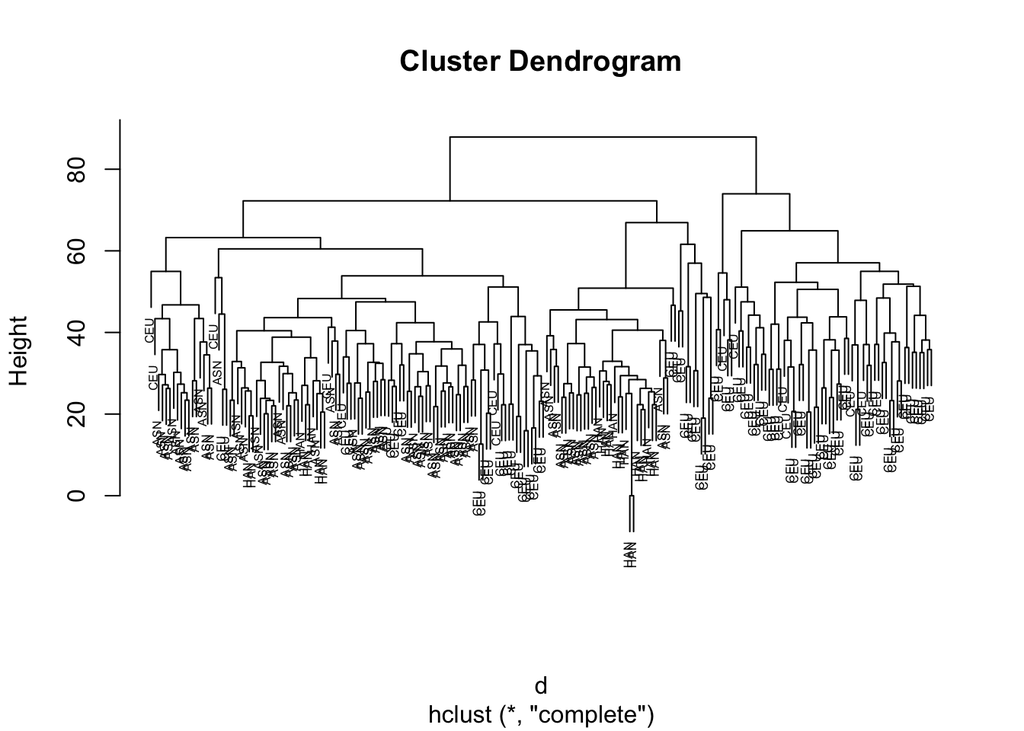

```r
plot(hc,labels=sampleinfo$ethnicity,cex=0.5)
```

It’s hard to see the “clusters”. One idea would be to color each sample by the ethnic group. For this, we will use the `mypclust()` function in the [`rafalib`](https://cran.r-project.org/package=rafalib) R package.

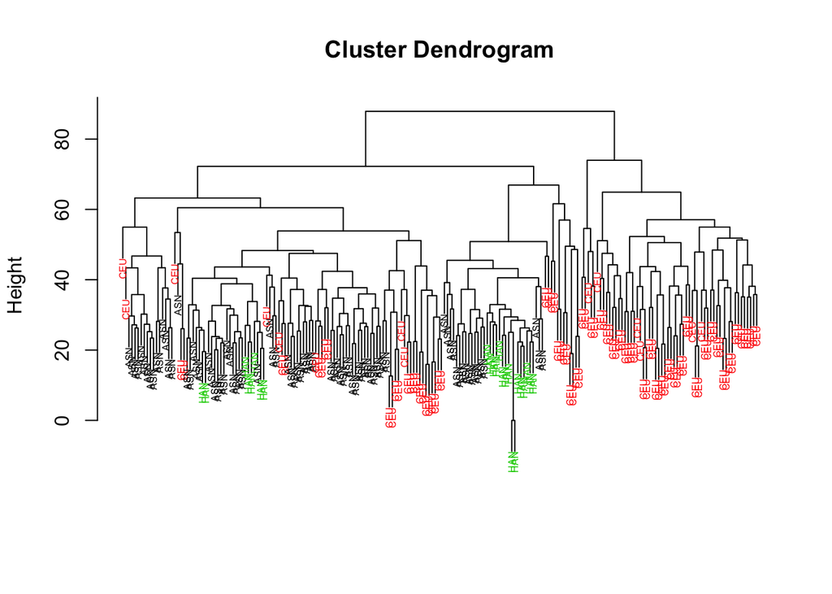

```r
library(rafalib)
myplclust(hc, labels=sampleinfo$ethnicity,
          lab.col=as.numeric(as.factor(sampleinfo$ethnicity)), cex=0.5)
```

We see that there seem to be some clusters, but it’s not very clear. There are CEU samples clustering together with the ASN samples, etc.

Also, note that hierarchical clustering does not define specific clusters, but rather defines the dendrogram above.

From the dendrogram we can decipher the distance between any two groups by looking at the height at which the two groups split into two.

To define clusters, we need to “cut the tree”" at some distance and group all samples that are within that distance into groups below. To visualize this, we draw a horizontal line at the height we wish to cut and this defines that line.

We use 73 as an example:

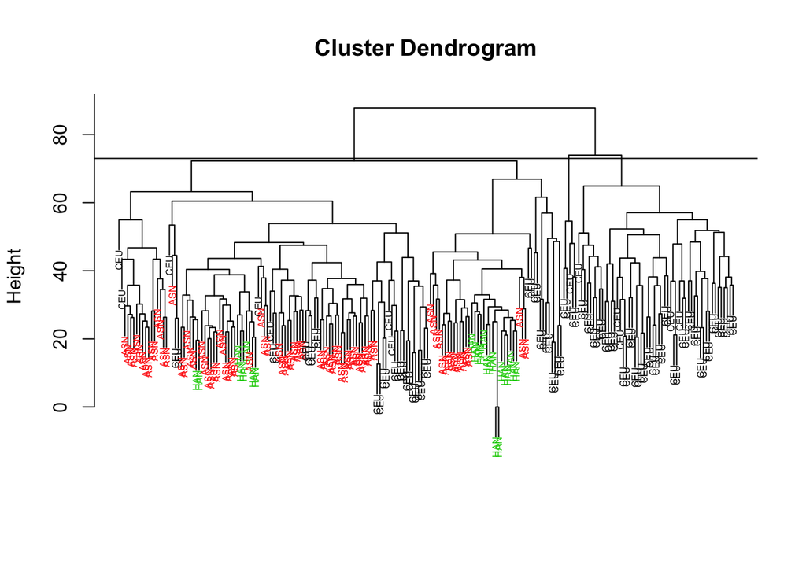

```r
myplclust(hc, labels=sampleinfo$ethnicity,
          lab.col=as.fumeric(sampleinfo$ethnicity), cex=0.5)
abline(h=73)
```

If we use the line above to cut the tree into clusters, we can examine how the clusters overlap with the actual ethnic groups:

```r
hclusters <- cutree(hc, h=73)
table(true=sampleinfo$ethnicity,
      cluster=hclusters)
```

```
##      cluster
## true   1  2  3
##   ASN 82  0  0
##   CEU 44 53  5
##   HAN 24  0  0
```

We can also ask cutree to give us back a given number of clusters. The function then automatically finds the height that results in the requested number of clusters:

```r
hclusters <- cutree(hc, k=3)
table(true=sampleinfo$ethnicity,
      cluster=hclusters)
```

```
##      cluster
## true   1  2  3
##   ASN 82  0  0
##   CEU 44 53  5
##   HAN 24  0  0
```

In both cases, we do not really see the samples clustering by ethnicity. For example, the CEU samples are spread across all three clusters. We will continue to explore this result to see what’s going on.

Before we leave this section, it’s important to note that selecting the number of clusters is generally a challenging step in practice and an active area of research.

## $k$-means clustering

Another approach to cluster is with the `kmeans()` function to perform $k$-means clustering.

This is a partioning approach. Given a set of $N$ observations ($\mathbf{x}$) and a fixed number of clusters ($k$), partion the data into $k$ clusters.

In practice, we use an iterative algorithm based on two steps:

1. **Assignment**: given a set of centroids, assign each observation to the closet centroid.
2. **Update**: compute new centroids for each cluster.

Requires

- A defined distance metric
- A number of clusters
- An initial guess as to cluster centroids (often random)

Produces

- Final estimate of cluster centroids
- An assignment of each point to clusters

Let’s run $k$-means on the samples in the space of the first two genes:

```r
set.seed(1000)
km <- kmeans(t(exprs[1:2,]), centers=3)
names(km)
```

```
## [1] "cluster"      "centers"      "totss"        "withinss"
## [5] "tot.withinss" "betweenss"    "size"         "iter"
## [9] "ifault"
```

If we plot the observations by ethnicity:

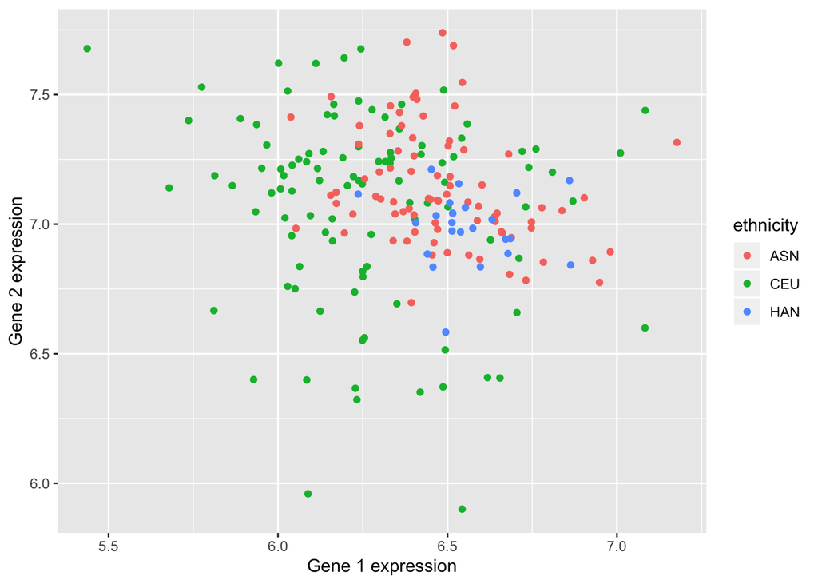

```r
new.dat <- data.frame(t(exprs[1:2,]),
                      sampleinfo,
                      "cluster"=factor(km$cluster))
new.dat %>%
  ggplot(aes(x=X1, y=X2, color=ethnicity)) +
  geom_point() + xlab("Gene 1 expression") +
  ylab("Gene 2 expression")
```

Since we don’t really see a great clusters, we might suspect k-means will have a hard time identifying the correct clusters.

However, it’s important to note that $k$-means will always find clusters

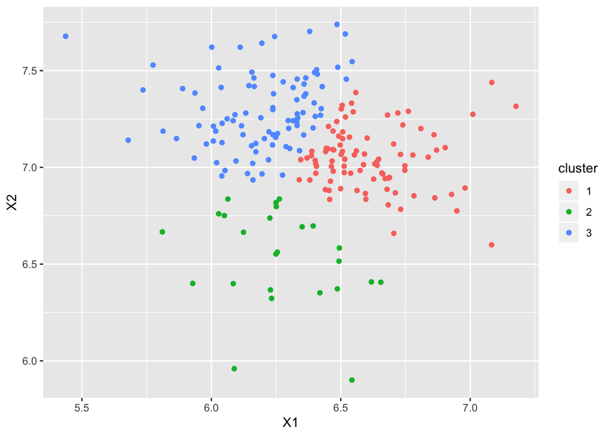

```r
new.dat %>%
  ggplot(aes(x=X1, y=X2, color = cluster)) +
  geom_point()
```

As suspected, we see $k$-means did not perform well:

```r
table(true=sampleinfo$ethnicity,
      cluster=km$cluster)
```

```
##      cluster
## true   1  2  3
##   ASN 48  1 33
##   CEU 21 23 58
##   HAN 22  1  1
```

This is very likely due to the fact the the first two genes are not informative regarding ethnicity. We can see this in the first plot above. If we instead perform $k$-means clustering using all of the genes:

```r
km <- kmeans(t(exprs), centers=3)
```

And then plot the samples along the first PCs (note that the columns – or genes here – are are centered by default)

```r
pc <- prcomp(t(exprs))
str(pc)
```

```
## List of 5
##  $ sdev    : num [1:208] 15.79 10.63 9.01 6.95 6.16 ...
##  $ rotation: num [1:8793, 1:208] 0.00973 0.00125 -0.01275 0.01324 0.00368 ...
##   ..- attr(*, "dimnames")=List of 2
##   .. ..$ : NULL
##   .. ..$ : chr [1:208] "PC1" "PC2" "PC3" "PC4" ...
##  $ center  : num [1:8793] 6.38 7.09 5.48 7.58 3.2 ...
##  $ scale   : logi FALSE
##  $ x       : num [1:208, 1:208] -9.02 -7.52 -21.68 -8.99 -21.5 ...
##   ..- attr(*, "dimnames")=List of 2
##   .. ..$ : chr [1:208] "GSM25349.CEL.gz" "GSM25350.CEL.gz" "GSM25356.CEL.gz" "GSM25357.CEL.gz" ...
##   .. ..$ : chr [1:208] "PC1" "PC2" "PC3" "PC4" ...
##  - attr(*, "class")= chr "prcomp"
```

Here is a plot of the first two PCs. We can see that the first two PCs will in fact be quite informative.

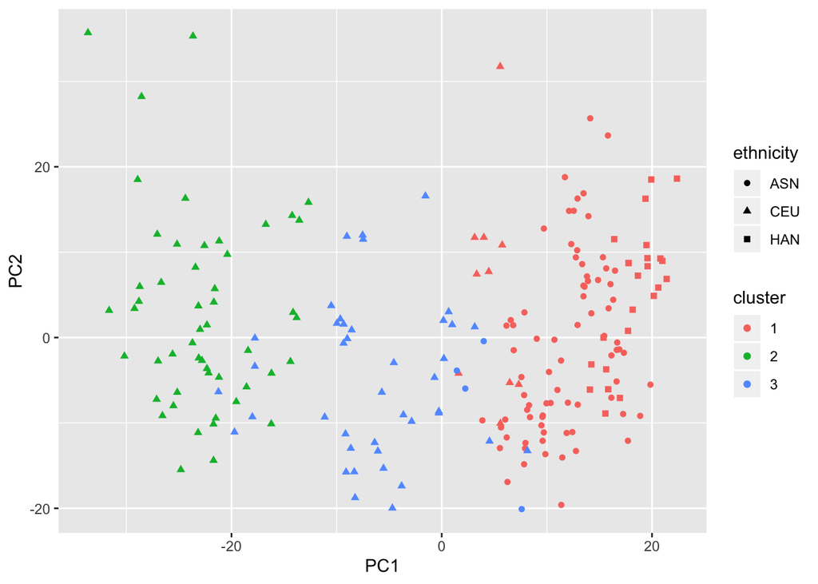

```r
new.dat <- data.frame(pc$x[,1:2], sampleinfo,
                      "cluster"=factor(km$cluster))
new.dat %>%
  ggplot(aes(x=PC1, y=PC2, color = cluster,
             shape = ethnicity)) + geom_point()
```

Note that it does in fact separate individuals by ethnicity. However, this visualization does illustrate a concerning characteristic: the CEU points seem to have sub-clusters.

What are these?

It turns out the date in which the microarray samples were processed also explain the clusters:

```r
library(lubridate)
```

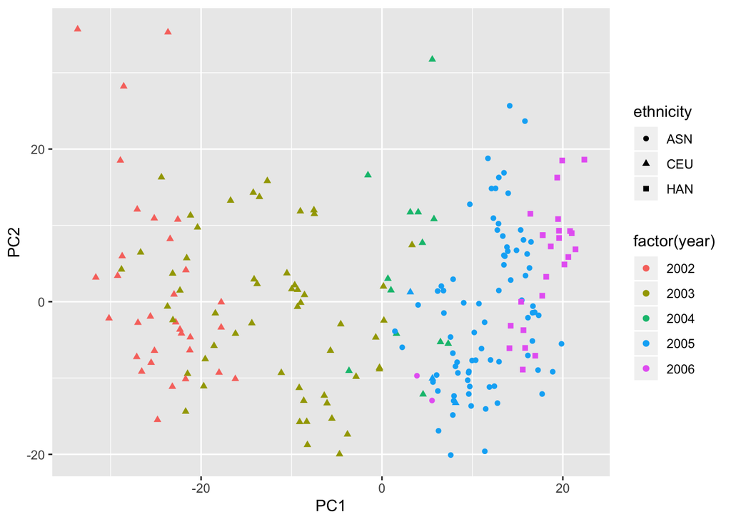

```r
sampleinfo$exprs_date <- ymd(sampleinfo$date)
sampleinfo$month <- month(sampleinfo$exprs_date )
sampleinfo$year <- year(sampleinfo$exprs_date )

new.dat <- data.frame(pc$x[,1:2], sampleinfo,
                      "cluster"=factor(km$cluster))
new.dat %>%
  ggplot(aes(x=PC1, y=PC2, color = factor(year),
             shape = ethnicity)) + geom_point()
```

Let’s explore this a bit more.

What’s the earliest date in our dataset?

```r
min(sampleinfo$exprs_date)
```

```
## [1] "2002-10-31"
```

OK, let’s convert the dates into days since Oct 31, 2002

```r
sampleinfo$days <- as.numeric(sampleinfo$exprs_date - min(sampleinfo$exprs_date) )
new.dat <- data.frame(pc$x[,1:2], sampleinfo, "cluster"=factor(km$cluster))
head(new.dat)
```

```
##                        PC1         PC2 ethnicity       date
## GSM25349.CEL.gz  -9.023798  11.8546543       CEU 2003-02-04
## GSM25350.CEL.gz  -7.524565  11.9976456       CEU 2003-02-04
## GSM25356.CEL.gz -21.680791   4.1466635       CEU 2002-12-17
## GSM25357.CEL.gz  -8.986556  -0.1278595       CEU 2003-01-30
## GSM25358.CEL.gz -21.495521  -9.4358053       CEU 2003-01-03
## GSM25359.CEL.gz -19.711037 -11.0687262       CEU 2003-01-16
##                        filename sex exprs_date month year days cluster
## GSM25349.CEL.gz GSM25349.CEL.gz   M 2003-02-04     2 2003   96       3
## GSM25350.CEL.gz GSM25350.CEL.gz   M 2003-02-04     2 2003   96       3
## GSM25356.CEL.gz GSM25356.CEL.gz   M 2002-12-17    12 2002   47       2
## GSM25357.CEL.gz GSM25357.CEL.gz   M 2003-01-30     1 2003   91       3
## GSM25358.CEL.gz GSM25358.CEL.gz   M 2003-01-03     1 2003   64       2
## GSM25359.CEL.gz GSM25359.CEL.gz   M 2003-01-16     1 2003   77       3
```

Now we will use EDA to explore how date has a large effect on the data.

Consider only the CEU ethnicity and compute the projection to the first principal component like this

```r
ind <- which(sampleinfo$ethnicity=="CEU")
pc <- prcomp(t(exprs[,ind]))
str(pc)
```

```
## List of 5
##  $ sdev    : num [1:102] 13.19 11.73 10.4 8.34 7.33 ...
##  $ rotation: num [1:8793, 1:102] -0.00692 -0.01402 0.01735 -0.00686 0.00188 ...
##   ..- attr(*, "dimnames")=List of 2
##   .. ..$ : NULL
##   .. ..$ : chr [1:102] "PC1" "PC2" "PC3" "PC4" ...
##  $ center  : num [1:8793] 6.26 7.08 5.6 7.42 3.13 ...
##  $ scale   : logi FALSE
##  $ x       : num [1:102, 1:102] -5.46 -6.19 3.08 -6.5 2.74 ...
##   ..- attr(*, "dimnames")=List of 2
##   .. ..$ : chr [1:102] "GSM25349.CEL.gz" "GSM25350.CEL.gz" "GSM25356.CEL.gz" "GSM25357.CEL.gz" ...
##   .. ..$ : chr [1:102] "PC1" "PC2" "PC3" "PC4" ...
##  - attr(*, "class")= chr "prcomp"
```

```r
new.dat <- data.frame(pc$x[,1:2], sampleinfo[ind,],
                      "cluster"=factor(km$cluster[ind]))
```

If we create a histogram of the first PC

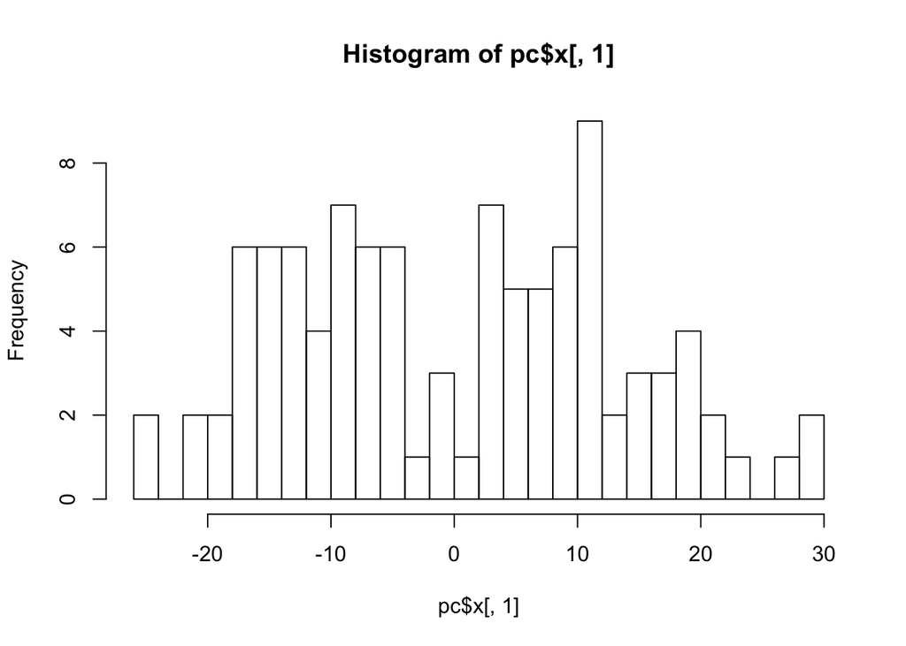

```r
hist(pc$x[,1], nc=25)
```

We see two modes. Now let’s plot the first PC against the date the samples were processed:

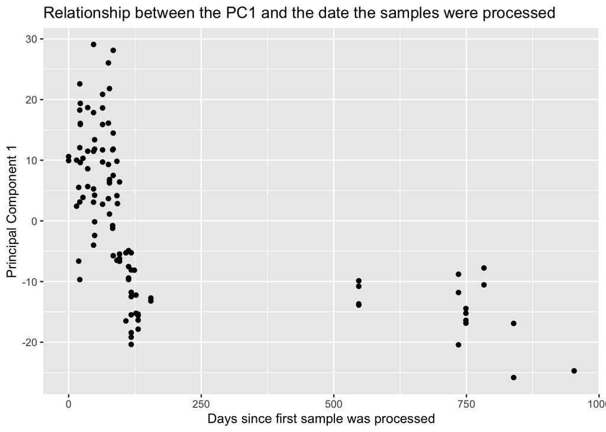

```r
new.dat %>%
  ggplot(aes(x=days, y=PC1)) + geom_point() +
  ggtitle("Relationship between the PC1 and the date the samples were processed") +
  xlab("Days since first sample was processed") +
  ylab("Principal Component 1")
```

Around what time do you notice a difference in the way the samples were processed?

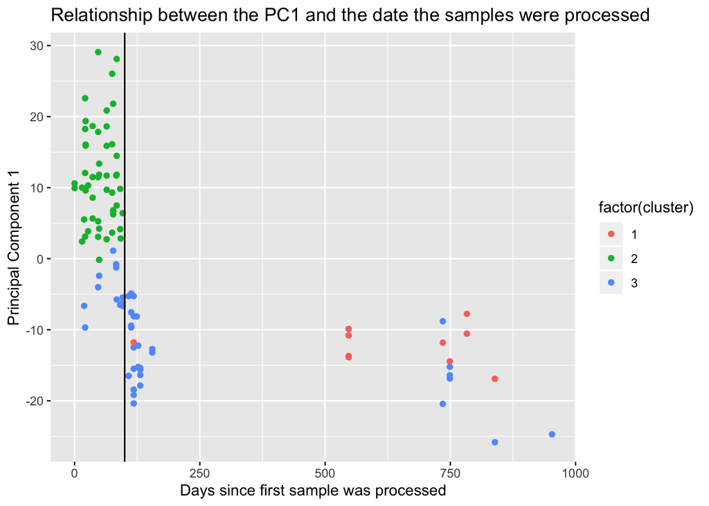

```r
new.dat %>%
  ggplot(aes(x=days, y=PC1, color=factor(cluster))) + geom_point() +
  ggtitle("Relationship between the PC1 and the date the samples were processed") +
  xlab("Days since first sample was processed") +
  ylab("Principal Component 1") +
  geom_vline(aes(xintercept=100))
```

We see a change around day 100, which also corresponds to the $k$-means cluster predictions.

## Model based clustering

One disadvantage of hierarchical clustering algorithms, and k-means algorithms is that they are largely heuristic and not based on formal models (meaning sample observations arise from a distribution that is a mixture of two or more components).

### Example: A pathological case

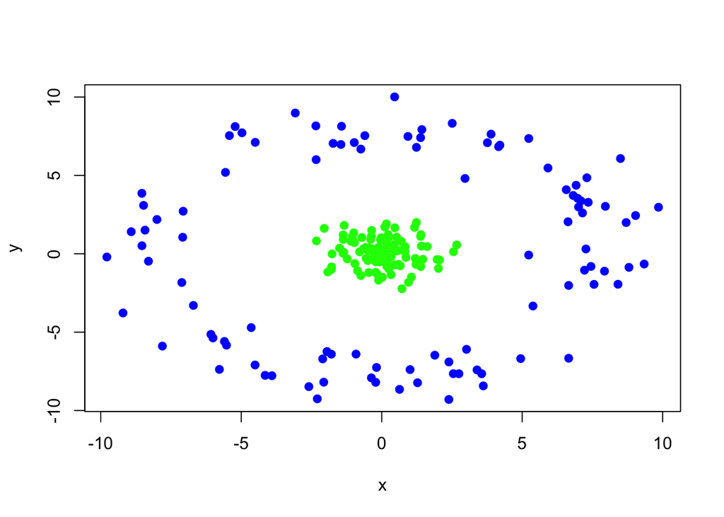

```r
clust1 = data.frame(x=rnorm(100),y=rnorm(100))

a = runif(100,0,2*pi)
clust2 = data.frame(x=8*cos(a) + rnorm(100),y=8*sin(a) + rnorm(100))

plot(clust2,col='blue',pch=19); points(clust1,col='green',pch=19)
```

If we apply `kmeans()`, we see

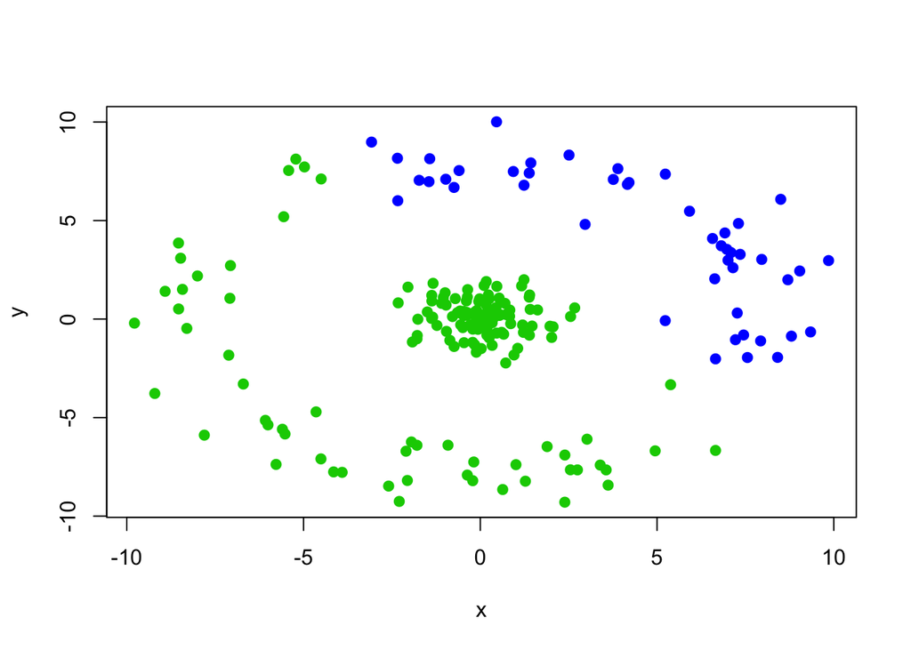

```r
dat = rbind(clust1,clust2)
kk = kmeans(dat,centers=2)
plot(dat,col=(kk$clust+2),pch=19)
```

## Summary of clustering approaches

- Algomerative (h-clustering) versus divisive (k-means)
- Distance matters!
- Merging matters!
- Number of clusters is rarely estimated in advance
- H-clustering: Deterministic - but you don’t get a fixed number of clusters
- K-means: Stochastic - fix the number of clusters in advance
- Model based: Can select the number of clusters, may be stochastic, careful about assumptions!

### What are some common evaluation methods used in cluster?

1. Sum of Squared Errors (SSE). If a cluster is very “compact” and well separated from others, it will have a small SSE.
2. If you have an external measure (i.e. gold standard), you can also try these:
- Rand Index. Compares the two clusters and tries to find the ratio of matching and unmatched observations among two clustering structures. Its value lies between 0 and 1.
- Precision Recall Measure. Derived from the confusion matrix. Recall is also known as “Sensitivity” [True Positive/ (True Positive + False Negative)]. For clustering, we use this measure from an information retrieval point of view. Here, precision is a measure of correctly retrieved items. Recall is measure of matching items from all the correctly retrieved items.